# Impact of Severe Weather Events on Public Health and Economy in the United States

Ulises González

2026-02-27

```r
knitr::opts_chunk$set(echo = TRUE, cache = TRUE, warning = FALSE, message = FALSE)
```

## Data Processing

### Loading Required Libraries

```r
library(dplyr)
library(ggplot2)
library(tidyr)
library(scales)
```

### Downloading and Reading the Data

We start from the raw `.csv.bz2` file. The data is downloaded directly from the course website and read into R.

```r
data_url <- "https://d396qusza40orc.cloudfront.net/repdata%2Fdata%2FStormData.csv.bz2"
data_file <- "StormData.csv.bz2"

if (!file.exists(data_file)) {
    download.file(data_url, destfile = data_file, method = "curl")
}

storm_data <- read.csv(data_file)
```

### Exploring the Dataset

```r
dim(storm_data)
```

```
## [1] 902297     37
```

```r
str(storm_data, list.len = 10)
```

```
## 'data.frame':    902297 obs. of  37 variables:
##  $ STATE__   : num  1 1 1 1 1 1 1 1 1 1 ...
##  $ BGN_DATE  : chr  "4/18/1950 0:00:00" "4/18/1950 0:00:00" "2/20/1951 0:00:00" "6/8/1951 0:00:00" ...
##  $ BGN_TIME  : chr  "0130" "0145" "1600" "0900" ...
##  $ TIME_ZONE : chr  "CST" "CST" "CST" "CST" ...
##  $ COUNTY    : num  97 3 57 89 43 77 9 123 125 57 ...
##  $ COUNTYNAME: chr  "MOBILE" "BALDWIN" "FAYETTE" "MADISON" ...
##  $ STATE     : chr  "AL" "AL" "AL" "AL" ...
##  $ EVTYPE    : chr  "TORNADO" "TORNADO" "TORNADO" "TORNADO" ...
##  $ BGN_RANGE : num  0 0 0 0 0 0 0 0 0 0 ...
##  $ BGN_AZI   : chr  "" "" "" "" ...
##   [list output truncated]
```

```r
head(storm_data[, c("EVTYPE", "FATALITIES", "INJURIES", "PROPDMG", "PROPDMGEXP", "CROPDMG", "CROPDMGEXP")])
```

```
##    EVTYPE FATALITIES INJURIES PROPDMG PROPDMGEXP CROPDMG CROPDMGEXP
## 1 TORNADO          0       15    25.0          K       0
## 2 TORNADO          0        0     2.5          K       0
## 3 TORNADO          0        2    25.0          K       0
## 4 TORNADO          0        2     2.5          K       0
## 5 TORNADO          0        2     2.5          K       0
## 6 TORNADO          0        6     2.5          K       0
```

### Processing Health Impact Data

We aggregate fatalities and injuries by event type to determine which events are most harmful to population health.

```r
health_data <- storm_data %>%
    group_by(EVTYPE) %>%
    summarise(
        fatalities = sum(FATALITIES, na.rm = TRUE),
        injuries = sum(INJURIES, na.rm = TRUE),
        total_health_impact = sum(FATALITIES, na.rm = TRUE) + sum(INJURIES, na.rm = TRUE)
    ) %>%
    arrange(desc(total_health_impact))

top_health <- head(health_data, 10)
top_health
```

```
## # A tibble: 10 × 4
##    EVTYPE            fatalities injuries total_health_impact
##    <chr>                  <dbl>    <dbl>               <dbl>
##  1 TORNADO                 5633    91346               96979
##  2 EXCESSIVE HEAT          1903     6525                8428
##  3 TSTM WIND                504     6957                7461
##  4 FLOOD                    470     6789                7259
##  5 LIGHTNING                816     5230                6046
##  6 HEAT                     937     2100                3037
##  7 FLASH FLOOD              978     1777                2755
##  8 ICE STORM                 89     1975                2064
##  9 THUNDERSTORM WIND        133     1488                1621
## 10 WINTER STORM             206     1321                1527
```

### Processing Economic Impact Data

Property and crop damage values use exponent codes (`PROPDMGEXP` and `CROPDMGEXP`) to indicate magnitude. We convert these codes to numeric multipliers and compute actual dollar amounts.

```r
convert_exp <- function(exp) {
    exp <- toupper(as.character(exp))
    case_when(
        exp == "H" ~ 1e2,
        exp == "K" ~ 1e3,
        exp == "M" ~ 1e6,
        exp == "B" ~ 1e9,
        exp %in% as.character(0:9) ~ 10^as.numeric(exp),
        TRUE ~ 1
    )
}

economic_data <- storm_data %>%
    mutate(
        prop_multiplier = convert_exp(PROPDMGEXP),
        crop_multiplier = convert_exp(CROPDMGEXP),
        property_damage = PROPDMG * prop_multiplier,
        crop_damage = CROPDMG * crop_multiplier,
        total_damage = property_damage + crop_damage
    )

economic_summary <- economic_data %>%
    group_by(EVTYPE) %>%
    summarise(
        property_damage = sum(property_damage, na.rm = TRUE),
        crop_damage = sum(crop_damage, na.rm = TRUE),
        total_damage = sum(total_damage, na.rm = TRUE)
    ) %>%
    arrange(desc(total_damage))

top_economic <- head(economic_summary, 10)
top_economic
```

```
## # A tibble: 10 × 4
##    EVTYPE            property_damage crop_damage  total_damage
##    <chr>                       <dbl>       <dbl>         <dbl>
##  1 FLOOD               144657709807   5661968450 150319678257
##  2 HURRICANE/TYPHOON    69305840000   2607872800  71913712800
##  3 TORNADO              56947380676.   414953270  57362333946.
##  4 STORM SURGE          43323536000         5000  43323541000
##  5 HAIL                 15735267513.  3025954473  18761221986.
##  6 FLASH FLOOD          16822673978.  1421317100  18243991078.
##  7 DROUGHT               1046106000  13972566000  15018672000
##  8 HURRICANE            11868319010   2741910000  14610229010
##  9 RIVER FLOOD           5118945500   5029459000  10148404500
## 10 ICE STORM             3944927860   5022113500   8967041360
```

We verify the exponent codes present in the data:

```r
table(storm_data$PROPDMGEXP)
```

```
##
##             -      ?      +      0      1      2      3      4      5      6
## 465934      1      8      5    216     25     13      4      4     28      4
##      7      8      B      h      H      K      m      M
##      5      1     40      1      6 424665      7  11330
```

```r
table(storm_data$CROPDMGEXP)
```

```
##
##             ?      0      2      B      k      K      m      M
## 618413      7     19      1      9     21 281832      1   1994
```

## Results

### Question 1: Events Most Harmful to Population Health

The following figure shows the top 10 weather event types by their impact on population health, including both fatalities and injuries.

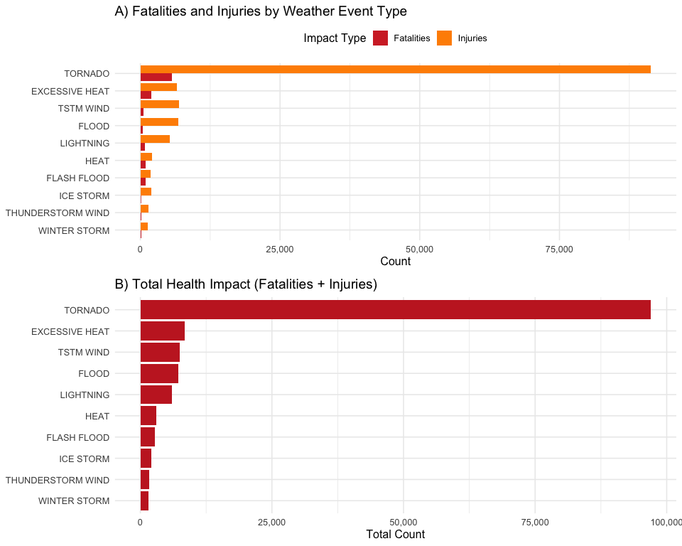

Figure 1: Top 10 weather events most harmful to population health in the United States (1950–2011). Panel A shows fatalities and injuries side by side. Panel B shows the combined health impact. Tornados dominate both categories by a wide margin.

```r
# Prepare data for side-by-side bar plot
health_long <- top_health %>%
    select(EVTYPE, fatalities, injuries) %>%
    pivot_longer(cols = c(fatalities, injuries), names_to = "type", values_to = "count") %>%
    mutate(
        EVTYPE = factor(EVTYPE, levels = rev(top_health$EVTYPE)),
        type = factor(type, levels = c("fatalities", "injuries"),
                      labels = c("Fatalities", "Injuries"))
    )

p1 <- ggplot(health_long, aes(x = EVTYPE, y = count, fill = type)) +
    geom_bar(stat = "identity", position = "dodge") +
    coord_flip() +
    scale_fill_manual(values = c("Fatalities" = "#D32F2F", "Injuries" = "#FF8F00")) +
    scale_y_continuous(labels = comma) +
    labs(
        title = "A) Fatalities and Injuries by Weather Event Type",
        x = NULL,
        y = "Count",
        fill = "Impact Type"
    ) +
    theme_minimal(base_size = 12) +
    theme(legend.position = "top")

# Total health impact
total_health_plot <- top_health %>%
    mutate(EVTYPE = factor(EVTYPE, levels = rev(EVTYPE)))

p2 <- ggplot(total_health_plot, aes(x = EVTYPE, y = total_health_impact)) +
    geom_bar(stat = "identity", fill = "#C62828") +
    coord_flip() +
    scale_y_continuous(labels = comma) +
    labs(
        title = "B) Total Health Impact (Fatalities + Injuries)",
        x = NULL,
        y = "Total Count"
    ) +
    theme_minimal(base_size = 12)

gridExtra::grid.arrange(p1, p2, ncol = 1)
```

**Key finding:** Tornados are overwhelmingly the most harmful weather event type to population health, causing **5,633** fatalities and **91,346** injuries over the period of record.

### Question 2: Events with Greatest Economic Consequences

The following figure shows the top 10 weather event types by their economic impact, split into property damage and crop damage.

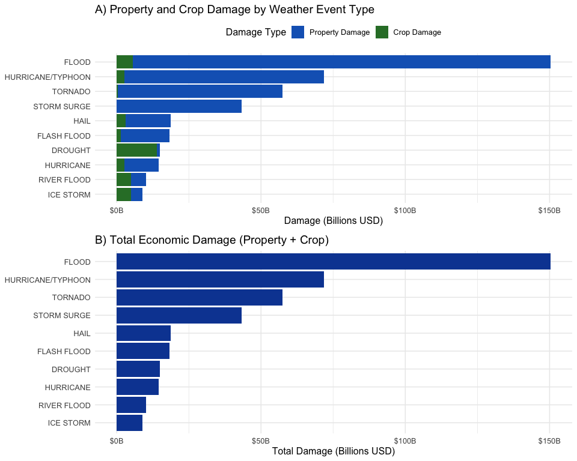

Figure 2: Top 10 weather events with greatest economic consequences in the United States (1950–2011). Panel A shows property and crop damage separately. Panel B shows total economic damage. Floods cause the largest combined economic losses.

```r
# Prepare data for stacked bar plot
econ_long <- top_economic %>%
    select(EVTYPE, property_damage, crop_damage) %>%
    pivot_longer(cols = c(property_damage, crop_damage), names_to = "type", values_to = "amount") %>%
    mutate(
        EVTYPE = factor(EVTYPE, levels = rev(top_economic$EVTYPE)),
        type = factor(type, levels = c("property_damage", "crop_damage"),
                      labels = c("Property Damage", "Crop Damage"))
    )

p3 <- ggplot(econ_long, aes(x = EVTYPE, y = amount / 1e9, fill = type)) +
    geom_bar(stat = "identity", position = "stack") +
    coord_flip() +
    scale_fill_manual(values = c("Property Damage" = "#1565C0", "Crop Damage" = "#2E7D32")) +
    scale_y_continuous(labels = dollar_format(suffix = "B")) +
    labs(
        title = "A) Property and Crop Damage by Weather Event Type",
        x = NULL,
        y = "Damage (Billions USD)",
        fill = "Damage Type"
    ) +
    theme_minimal(base_size = 12) +
    theme(legend.position = "top")

# Total economic damage
total_econ_plot <- top_economic %>%
    mutate(EVTYPE = factor(EVTYPE, levels = rev(EVTYPE)))

p4 <- ggplot(total_econ_plot, aes(x = EVTYPE, y = total_damage / 1e9)) +
    geom_bar(stat = "identity", fill = "#0D47A1") +
    coord_flip() +
    scale_y_continuous(labels = dollar_format(suffix = "B")) +
    labs(
        title = "B) Total Economic Damage (Property + Crop)",
        x = NULL,
        y = "Total Damage (Billions USD)"
    ) +
    theme_minimal(base_size = 12)

gridExtra::grid.arrange(p3, p4, ncol = 1)
```

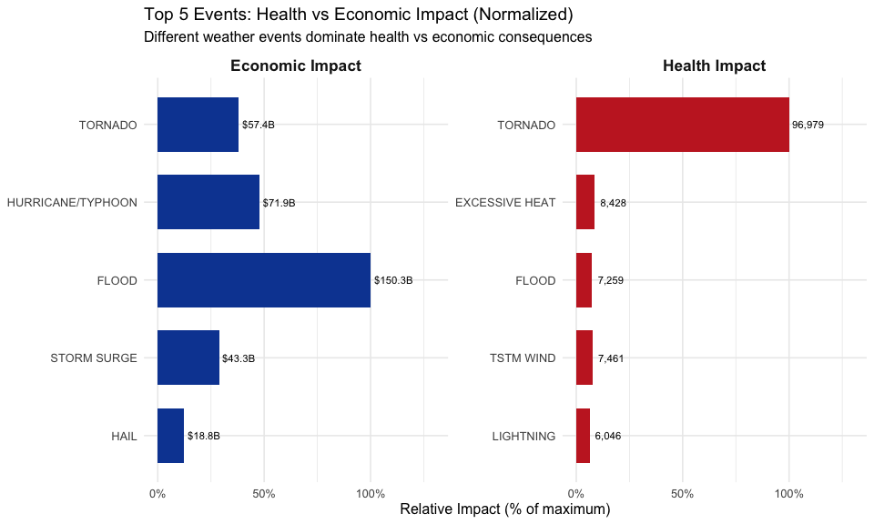

Figure 3: Comparison of the top 5 events for health impact vs economic impact, highlighting that different event types dominate each category.

```r
top5_health <- head(health_data, 5) %>%
    mutate(rank = row_number()) %>%
    select(rank, event_health = EVTYPE, total_health_impact)

top5_econ <- head(economic_summary, 5) %>%
    mutate(rank = row_number()) %>%
    select(rank, event_economic = EVTYPE, total_damage)

# Create a comparison visualization
comparison <- bind_rows(
    head(health_data, 5) %>%
        mutate(
            category = "Health Impact",
            value = total_health_impact / max(total_health_impact),
            label = format(total_health_impact, big.mark = ","),
            rank = row_number()
        ) %>%
        select(EVTYPE, category, value, label, rank),
    head(economic_summary, 5) %>%
        mutate(
            category = "Economic Impact",
            value = total_damage / max(total_damage),
            label = paste0("$", round(total_damage / 1e9, 1), "B"),
            rank = row_number()
        ) %>%
        select(EVTYPE, category, value, label, rank)
)

ggplot(comparison, aes(x = reorder(EVTYPE, -rank), y = value, fill = category)) +
    geom_bar(stat = "identity", position = "dodge", width = 0.7) +
    geom_text(aes(label = label), position = position_dodge(width = 0.7),
              hjust = -0.1, size = 3) +
    coord_flip() +
    scale_fill_manual(values = c("Health Impact" = "#C62828", "Economic Impact" = "#0D47A1")) +
    scale_y_continuous(limits = c(0, 1.3), labels = percent) +
    facet_wrap(~category, scales = "free") +
    labs(
        title = "Top 5 Events: Health vs Economic Impact (Normalized)",
        subtitle = "Different weather events dominate health vs economic consequences",
        x = NULL,
        y = "Relative Impact (% of maximum)"
    ) +
    theme_minimal(base_size = 12) +
    theme(legend.position = "none",
          strip.text = element_text(face = "bold", size = 13))
```

### Conclusions

1. **Population Health:** Tornados are the single most dangerous weather event, responsible for the most fatalities and injuries combined. Excessive heat ranks second for fatalities, while thunderstorm winds rank second for injuries.
2. **Economic Consequences:** Floods cause the greatest total economic damage, primarily through property destruction. Hurricanes/typhoons and storm surges are also major economic threats. Drought stands out as causing disproportionately high crop damage relative to property damage.
3. **Policy Implication:** Resources for public health preparedness should prioritize tornado warning systems and shelters, while economic preparedness should focus on flood mitigation infrastructure and hurricane resilience.